# PracticalHw2_SVM

2025-04-16

## Introduction

The second practical homework will explore the use of support vector models for classification. Using the concepts from our two lectures on support vector models, your task is to explore how health behaviors impact health outcomes. The data was collected via the National Health Interview Survey and was accessed through IPUMS Health Survey<sup>1</sup>. This data set contains variables regarding respondent’s demographics, 5 major health conditions such as (cancer, heart disease, diabetes, heart attack and stroke) and their lifestyle and behaviors like work hours, physical activity, sleep habits, and eating habits. Details about the specific variables and the key to decoding the meaning of numeric values for each variable can be found in the codebook.

**Your task is to predict the presence of one of these 5 diseases based on demographics and habits.**

You should explore and be creative with your answers. The main task is to perform the prediction, but you should also interrogate the data and pose questions that are interesting to you.

You are welcome to subset the data in any way you like, e.g. only look at married couples, or only focus on children, but you should investigate the relationships among at least **5 total variables and the 3 models types (linear, radial, and polynomial kernels).** The 5 variables do not each have to be in every model.

## Data Cleaning

First, we will import the National Health Interview Survey data set. According to Medical News Today, the onset of diabetes is most common for people ages 45 to 65, therefore we will subset the data to adults who are 45 years old or older to see what demographics and habits as older adults can predict diabetes ([Medical News Today](https://www.medicalnewstoday.com/articles/317375)).

```r
# import data
nhis <- read.csv("nhis_2022.csv")

# filter age over 45
library(dplyr)
nhis <- nhis %>%
  filter(AGE >= 45)
```

```r
### Explore Target Variables

# check classifications
table(nhis$DIABETICEV)
```

```
##
##     1     2     7     9
## 14888  2704    21     8
```

```r
nhis <- nhis %>%
  filter(DIABETICEV %in% c(1, 2)) %>%
  mutate(
    DIABETICEV = ifelse(DIABETICEV == 2, 1, 0)
  )
  # recode target variable: 0 = No and 1 = Yes

# ensure target variable is treated as factor (classification)
nhis$DIABETICEV <- factor(nhis$DIABETICEV, levels = c(0, 1), labels = c("No", "Yes"))
table(nhis$DIABETICEV)
```

```
##
##    No   Yes
## 14888  2704
```

```r
### Renaming Variables
nhis <- nhis %>%
  rename(
    survey_year = YEAR,
    household_serial = SERIAL,
    variance_stratum = STRATA,
    primary_sampling_unit = PSU,
    household_id = NHISHID,
    region = REGION,
    person_number = PERNUM,
    person_id = NHISPID,
    household_number = HHX,
    sample_weight = SAMPWEIGHT,
    sample_adult_flag = ASTATFLG,
    sample_child_flag = CSTATFLG,
    age = AGE,
    sex = SEX,
    marital_status = MARSTCUR,
    education_level = EDUC,
    hours_worked_wk = HOURSWRK,
    poverty_ratio = POVERTY,
    height_in = HEIGHT,
    weight_lb = WEIGHT,
    bmi = BMICALC,
    health_insurance_status = HINOTCOVE,
    ever_had_cancer = CANCEREV,
    ever_had_heart_disease = CHEARTDIEV,
    ever_had_diabetes = DIABETICEV,
    ever_had_heart_attack = HEARTATTEV,
    ever_had_stroke = STROKEV,
    alcohol_frequency_units = ALCANYNO,
    alcohol_days_past_year = ALCDAYSYR,
    smoking_days_past_30 = CIGDAYMO,
    moderate_activity_minutes = MOD10DMIN,
    vigorous_activity_minutes = VIG10DMIN,
    fruit_intake = FRUTNO,
    vegetable_intake = VEGENO,
    juice_intake = JUICEMNO,
    salad_intake = SALADSNO,
    bean_intake = BEANNO,
    salsa_intake = SALSAMNO,
    tomato_sauce_intake = TOMSAUCEMNO,
    soda_intake = SODAPNO,
    fried_potatoes_intake = FRIESPNO,
    sports_drink_intake = SPORDRMNO,
    fruit_drink_intake = FRTDRINKMNO,
    coffee_tea_intake = COFETEAMNO,
    nonfried_potatoes_intake = POTATONO,
    pizza_intake = PIZZANO,
    hours_sleep = HRSLEEP,
    covid_vaccination = CVDSHT
  )
```

```r
### Data Subsets

# demographic + socioeconomic
# identify population-level disparities in diabetes risk
demo_socio <- nhis %>%
  select(ever_had_diabetes, age, sex, marital_status, education_level, poverty_ratio, hours_worked_wk, hours_sleep)

# body composition and health insurance
# weight and insurance access affects diabetes risk
body_health <- nhis %>%
  select(ever_had_diabetes, height_in, weight_lb, bmi, age, sex,alcohol_days_past_year, smoking_days_past_30)

# dietary habits
# eating factors that are associated with diabetes risk
diet <- nhis %>%
  select(ever_had_diabetes, fruit_intake, vegetable_intake, juice_intake, salad_intake,soda_intake, fried_potatoes_intake, fruit_drink_intake, pizza_intake)

# physical activity and sleep
lifestyle <- nhis %>%
  select(ever_had_diabetes, moderate_activity_minutes, vigorous_activity_minutes, hours_sleep)
```

### Linear SVM Model: Predicting Diabetes with Demographic and Socio-Economic Factors

```r
### Cleaning demographic and socio economic data
demo_socio <- nhis %>%
  select(ever_had_diabetes, age, sex, marital_status, poverty_ratio, hours_worked_wk, hours_sleep)
summary(demo_socio)
```

```
##  ever_had_diabetes      age              sex        marital_status
##  No :14888         Min.   : 45.00   Min.   :1.000   Min.   :1.000
##  Yes: 2704         1st Qu.: 56.00   1st Qu.:1.000   1st Qu.:1.000
##                    Median : 65.00   Median :2.000   Median :5.000
##                    Mean   : 67.91   Mean   :1.554   Mean   :3.802
##                    3rd Qu.: 73.00   3rd Qu.:2.000   3rd Qu.:6.000
##                    Max.   :999.00   Max.   :7.000   Max.   :9.000
##  poverty_ratio   hours_worked_wk  hours_sleep
##  Min.   :11.00   Min.   : 0.00   Min.   : 1.00
##  1st Qu.:24.00   1st Qu.: 0.00   1st Qu.: 6.00
##  Median :34.00   Median : 0.00   Median : 7.00
##  Mean   :30.68   Mean   :17.15   Mean   :10.13
##  3rd Qu.:37.00   3rd Qu.:40.00   3rd Qu.: 8.00
##  Max.   :37.00   Max.   :99.00   Max.   :99.00
```

```r
demo_socio <- demo_socio %>%
  filter(
    age >= 45 & age <= 65,                          # ages 45-65
    sex %in% c(1, 2),                               # 1 = Male, 2 = Female
    marital_status %in% 1:8,                        # Valid codes
    poverty_ratio >= 0 & poverty_ratio <= 37,       # Max observed 37
    hours_worked_wk >= 0 & hours_worked_wk <= 95,
    hours_sleep >= 3 & hours_sleep <= 18            # Reasonable sleep
  )
summary(demo_socio)
```

```
##  ever_had_diabetes      age             sex        marital_status
##  No :7674          Min.   :45.00   Min.   :1.000   Min.   :1.000
##  Yes:1108          1st Qu.:51.00   1st Qu.:1.000   1st Qu.:1.000
##                    Median :56.00   Median :2.000   Median :1.000
##                    Mean   :55.79   Mean   :1.541   Mean   :3.434
##                    3rd Qu.:61.00   3rd Qu.:2.000   3rd Qu.:5.000
##                    Max.   :65.00   Max.   :2.000   Max.   :8.000
##  poverty_ratio   hours_worked_wk  hours_sleep
##  Min.   :11.00   Min.   : 0.0    Min.   : 3.000
##  1st Qu.:31.00   1st Qu.: 0.0    1st Qu.: 6.000
##  Median :35.00   Median :40.0    Median : 7.000
##  Mean   :31.18   Mean   :28.8    Mean   : 6.999
##  3rd Qu.:37.00   3rd Qu.:40.0    3rd Qu.: 8.000
##  Max.   :37.00   Max.   :95.0    Max.   :18.000
```

```r
### SVM on Diet Subset
library(e1071)
# Train-test split
set.seed(1)
index <- sample(1:nrow(demo_socio), 0.7 * nrow(demo_socio)) # 70/30 split
train <- demo_socio[index, ]
test <- demo_socio[-index, ]

# (b) Fit SVM model
svm_model <- svm(ever_had_diabetes ~ ., data = train, kernel = 'linear', cost = 1)

# Summary statistics of SVM model
summary(svm_model)
```

```
##
## Call:
## svm(formula = ever_had_diabetes ~ ., data = train, kernel = "linear",
##     cost = 1)
##
##
## Parameters:
##    SVM-Type:  C-classification
##  SVM-Kernel:  linear
##        cost:  1
##
## Number of Support Vectors:  1533
##
##  ( 755 778 )
##
##
## Number of Classes:  2
##
## Levels:
##  No Yes
```

```r
# (c) Training error
sum(predict(svm_model, train) != train$ever_had_diabetes)/nrow(train)
```

```
## [1] 0.1228241
```

```r
# Test error
sum(predict(svm_model, test) != test$ever_had_diabetes)/nrow(test)
```

```
## [1] 0.1339658
```

```r
### Confusion Matrix
true_values <- test$ever_had_diabetes
predicted_values <- predict(svm_model, newdata = test)
conf_matrix <- table(true = true_values, pred = predicted_values)
conf_matrix
```

```
##      pred
## true    No  Yes
##   No  2282    0
##   Yes  353    0
```

```r
### Undersample classes
set.seed(1)

# Subset each class
no_cases <- demo_socio[demo_socio$ever_had_diabetes == "No", ]
yes_cases <- demo_socio[demo_socio$ever_had_diabetes == "Yes", ]

# Undersample 1000 from each class
no_sample <- no_cases[sample(nrow(no_cases), 1000), ]
yes_sample <- yes_cases[sample(nrow(yes_cases), 1000), ]

# Combine into a balanced, undersampled dataset
demo_socio_undersampled <- rbind(no_sample, yes_sample)

# Shuffle rows
demo_socio_undersampled <- demo_socio_undersampled[sample(nrow(demo_socio_undersampled)), ]

# Check result
table(demo_socio_undersampled$ever_had_diabetes)
```

```
##
##   No  Yes
## 1000 1000
```

```r
### Cross-Validation SVM
set.seed(1)

# 70/30 train-test split
index <- sample(1:nrow(demo_socio_undersampled), 0.7 * nrow(demo_socio_undersampled))
train <- demo_socio_undersampled[index, ]
test <- demo_socio_undersampled[-index, ]

# Scale numeric predictors (excluding the target variable)
train_scaled <- train %>%
  mutate(across(-ever_had_diabetes, scale))

test_scaled <- test %>%
  mutate(across(-ever_had_diabetes, scale))


# (d) Cross-validation on SVM models
set.seed(1)
tune_model <- tune(
  svm, ever_had_diabetes ~ ., data = train_scaled,
  kernel = "linear",
  ranges = list(cost = c(1, 5, 10, 50, 100))
)

# Pick best model
tune_model$best.parameters
```

```
##   cost
## 3   10
```

```r
bestmod <- tune_model$best.model
summary(bestmod)
```

```
##
## Call:
## best.tune(METHOD = svm, train.x = ever_had_diabetes ~ ., data = train_scaled,
##     ranges = list(cost = c(1, 5, 10, 50, 100)), kernel = "linear")
##
##
## Parameters:
##    SVM-Type:  C-classification
##  SVM-Kernel:  linear
##        cost:  10
##
## Number of Support Vectors:  1168
##
##  ( 584 584 )
##
##
## Number of Classes:  2
##
## Levels:
##  No Yes
```

```r
# (e) Training error with best model
sum(predict(bestmod, train_scaled) != train_scaled$ever_had_diabetes)/nrow(train_scaled)
```

```
## [1] 0.3814286
```

```r
# Test error with best model
sum(predict(bestmod, test_scaled) != test_scaled$ever_had_diabetes)/nrow(test_scaled)
```

```
## [1] 0.4283333
```

```r
### Confusion Matrix
true_values <- test_scaled$ever_had_diabetes
predicted_values <- predict(bestmod, newdata = test_scaled)

conf_matrix <- table(true = true_values, pred = predicted_values)
conf_matrix
```

```
##      pred
## true   No Yes
##   No  182  86
##   Yes 171 161
```

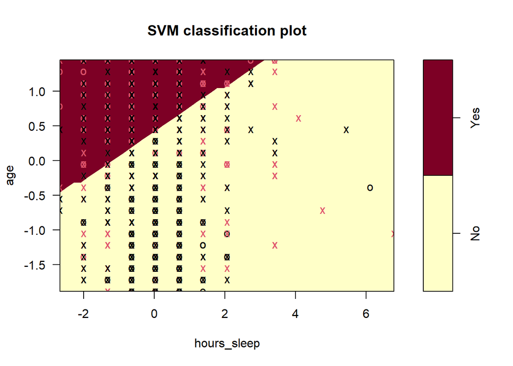

```r
### Plots
plot(bestmod, train_scaled, age ~ hours_sleep)
```

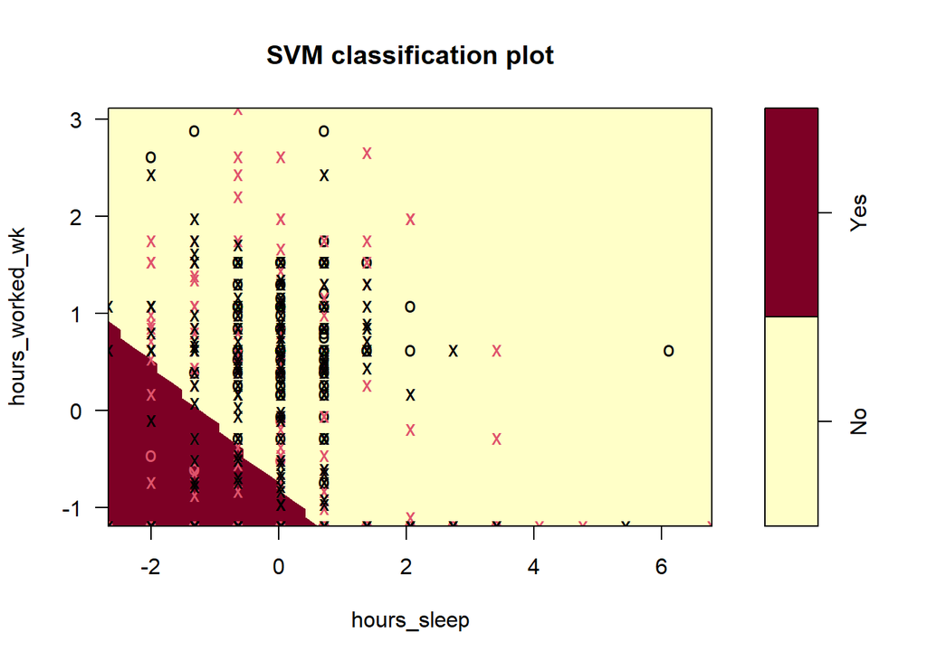

```r
plot(bestmod, train_scaled, hours_worked_wk ~ hours_sleep)
```

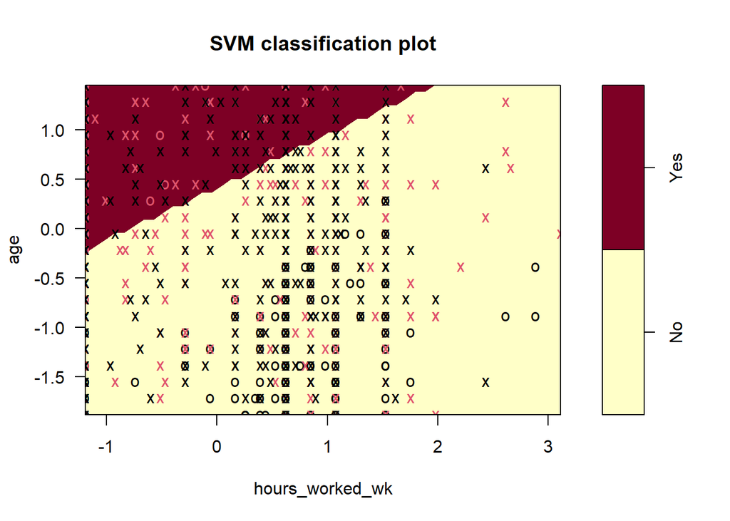

```r
plot(bestmod, train_scaled, age ~ hours_worked_wk)
```

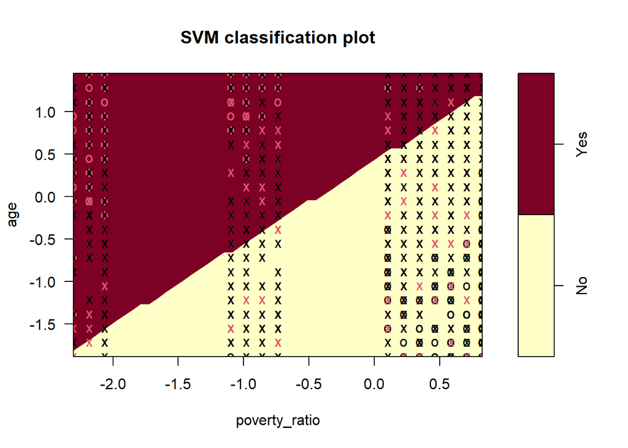

```r
plot(bestmod, train_scaled, age ~ poverty_ratio)
```

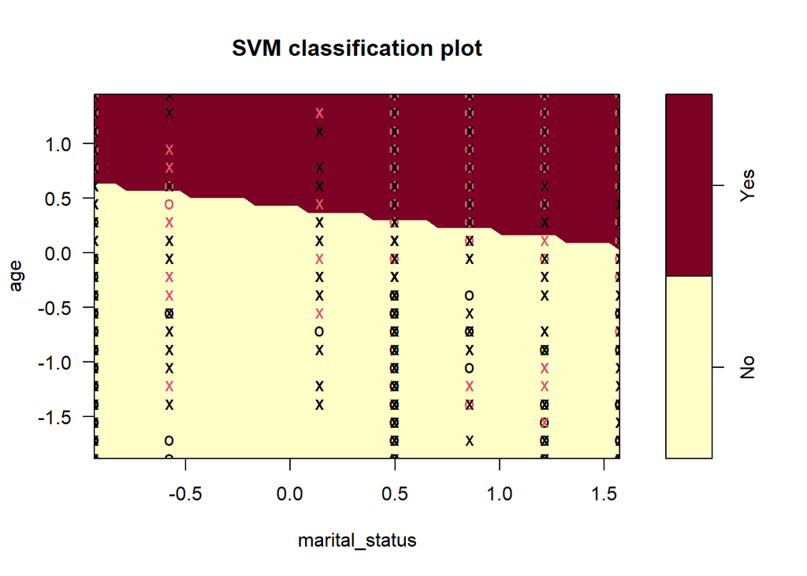

```r
plot(bestmod, train_scaled, age ~ marital_status)
```

### Polynomial SVM Model: Predicting Diabetes by Body Composition and Health Factors

```r
### Clean body and health data
body_health <- nhis %>%
  select(ever_had_diabetes, height_in, weight_lb, bmi, age, sex,alcohol_days_past_year, smoking_days_past_30)

summary(body_health)
```

```
##  ever_had_diabetes   height_in       weight_lb          bmi
##  No :14888         Min.   :59.00   Min.   :100.0   Min.   : 15.2
##  Yes: 2704         1st Qu.:64.00   1st Qu.:150.0   1st Qu.: 24.4
##                    Median :67.00   Median :180.0   Median : 28.1
##                    Mean   :68.34   Mean   :243.5   Mean   :107.3
##                    3rd Qu.:70.00   3rd Qu.:215.0   3rd Qu.: 32.9
##                    Max.   :99.00   Max.   :999.0   Max.   :996.0
##       age              sex        alcohol_days_past_year smoking_days_past_30
##  Min.   : 45.00   Min.   :1.000   Min.   :  0.0          Min.   : 0.00
##  1st Qu.: 56.00   1st Qu.:1.000   1st Qu.:  1.0          1st Qu.:96.00
##  Median : 65.00   Median :2.000   Median : 24.0          Median :96.00
##  Mean   : 67.91   Mean   :1.554   Mean   :200.1          Mean   :94.19
##  3rd Qu.: 73.00   3rd Qu.:2.000   3rd Qu.:208.0          3rd Qu.:96.00
##  Max.   :999.00   Max.   :7.000   Max.   :999.0          Max.   :99.00
```

```r
library(dplyr)
body_health <- body_health %>%
  filter(
    height_in >= 50 & height_in <= 84,         # 4ft 2in to 7ft
    weight_lb >= 80 & weight_lb <= 500,        # 80–500 lbs
    bmi >= 10 & bmi <= 70,                     # BMI range
    age >= 45 & age <= 65,                    # Limit 45-65
    sex %in% c(1, 2),                          # 1 = Male, 2 = Female
    alcohol_days_past_year <= 365,             # At most 365 days/year
  )

summary(body_health)
```

```
##  ever_had_diabetes   height_in       weight_lb          bmi
##  No :6550          Min.   :59.00   Min.   :100.0   Min.   :15.20
##  Yes: 873          1st Qu.:64.00   1st Qu.:153.0   1st Qu.:24.40
##                    Median :67.00   Median :180.0   Median :28.00
##                    Mean   :66.99   Mean   :183.5   Mean   :28.66
##                    3rd Qu.:70.00   3rd Qu.:210.0   3rd Qu.:32.00
##                    Max.   :76.00   Max.   :299.0   Max.   :50.80
##       age             sex        alcohol_days_past_year smoking_days_past_30
##  Min.   :45.00   Min.   :1.000   Min.   :  0.00         Min.   : 0.00
##  1st Qu.:51.00   1st Qu.:1.000   1st Qu.:  2.00         1st Qu.:96.00
##  Median :57.00   Median :2.000   Median : 24.00         Median :96.00
##  Mean   :55.88   Mean   :1.516   Mean   : 70.43         Mean   :93.39
##  3rd Qu.:61.00   3rd Qu.:2.000   3rd Qu.:104.00         3rd Qu.:96.00
##  Max.   :65.00   Max.   :2.000   Max.   :365.00         Max.   :99.00
```

```r
### Undersample classes
set.seed(1)

# Subset each class
no_cases <- body_health[body_health$ever_had_diabetes == "No", ]
yes_cases <- body_health[body_health$ever_had_diabetes == "Yes", ]

# Undersample 1000 from each class
no_sample <- no_cases[sample(nrow(no_cases), 873), ]
yes_sample <- yes_cases[sample(nrow(yes_cases), 873), ]

# Combine into a balanced, undersampled dataset
health_undersampled <- rbind(no_sample, yes_sample)

# Shuffle rows
health_undersampled <- health_undersampled[sample(nrow(health_undersampled)), ]

# Check result
table(health_undersampled$ever_had_diabetes)
```

```
##
##  No Yes
## 873 873
```

```r
### Polynomial SVM Model (degree 2)
set.seed(1)

# 70/30 train-test split
index <- sample(1:nrow(health_undersampled), 0.7 * nrow(health_undersampled))
train <- health_undersampled[index, ]
test <- health_undersampled[-index, ]

# Scale numeric predictors (excluding the target variable)
train_scaled <- train %>%
  mutate(across(-ever_had_diabetes, scale))

test_scaled <- test %>%
  mutate(across(-ever_had_diabetes, scale))

# (b) Fit the SVM model with a polynomial kernel
svm_model <- svm(ever_had_diabetes ~ ., data = train_scaled, kernel = 'polynomial', degree = 2, cost = 1)

# Summary statistics of the SVM model
summary(svm_model)
```

```
##
## Call:
## svm(formula = ever_had_diabetes ~ ., data = train_scaled, kernel = "polynomial",
##     degree = 2, cost = 1)
##
##
## Parameters:
##    SVM-Type:  C-classification
##  SVM-Kernel:  polynomial
##        cost:  1
##      degree:  2
##      coef.0:  0
##
## Number of Support Vectors:  1116
##
##  ( 557 559 )
##
##
## Number of Classes:  2
##
## Levels:
##  No Yes
```

```r
# (c) Training error
ypred <- predict(svm_model, newdata = train_scaled)
mean(ypred != train_scaled$ever_had_diabetes)
```

```
## [1] 0.4148936
```

```r
# (d) Test error
ypred_test <- predict(svm_model, newdata = test_scaled)
mean(ypred_test != test_scaled$ever_had_diabetes)
```

```
## [1] 0.4446565
```

```r
### Confusion Matrix
true_values <- test_scaled$ever_had_diabetes
predicted_values <- predict(svm_model, newdata = test_scaled)
conf_matrix <- table(true = true_values, pred = predicted_values)
conf_matrix
```

```
##      pred
## true   No Yes
##   No  152 108
##   Yes 125 139
```

```r
### Polynomial SVM Model (degree 3)
# (b) Fit the SVM model with a polynomial kernel
svm_model <- svm(ever_had_diabetes ~ ., data = train_scaled, kernel = 'polynomial', degree = 3, cost = 1)

# Summary statistics of the SVM model
summary(svm_model)
```

```
##
## Call:
## svm(formula = ever_had_diabetes ~ ., data = train_scaled, kernel = "polynomial",
##     degree = 3, cost = 1)
##
##
## Parameters:
##    SVM-Type:  C-classification
##  SVM-Kernel:  polynomial
##        cost:  1
##      degree:  3
##      coef.0:  0
##
## Number of Support Vectors:  1000
##
##  ( 498 502 )
##
##
## Number of Classes:  2
##
## Levels:
##  No Yes
```

```r
# (c) Training error
ypred <- predict(svm_model, newdata = train_scaled)
mean(ypred != train_scaled$ever_had_diabetes)
```

```
## [1] 0.3420622
```

```r
# (d) Test error
ypred_test <- predict(svm_model, newdata = test_scaled)
mean(ypred_test != test_scaled$ever_had_diabetes)
```

```
## [1] 0.3645038
```

```r
### Confusion Matrix
true_values <- test_scaled$ever_had_diabetes
predicted_values <- predict(svm_model, newdata = test_scaled)
conf_matrix <- table(true = true_values, pred = predicted_values)
conf_matrix
```

```
##      pred
## true   No Yes
##   No  164  96
##   Yes  95 169
```

```r
# (e) Cross-validation for tuning the model
# cv model
set.seed(1)
tune_model <- tune(svm, ever_had_diabetes ~ .,
                   data = train_scaled,
                   kernel = "polynomial",
                   ranges = list(cost = c(0.1, 1, 5, 10, 50, 100),
                                 degree = c(2,3,4)))

# Pick the best model based on cross-validation results
bestmod <- tune_model$best.model
summary(bestmod)
```

```
##
## Call:
## best.tune(METHOD = svm, train.x = ever_had_diabetes ~ ., data = train_scaled,
##     ranges = list(cost = c(0.1, 1, 5, 10, 50, 100), degree = c(2,
##         3, 4)), kernel = "polynomial")
##
##
## Parameters:
##    SVM-Type:  C-classification
##  SVM-Kernel:  polynomial
##        cost:  1
##      degree:  3
##      coef.0:  0
##
## Number of Support Vectors:  1000
##
##  ( 498 502 )
##
##
## Number of Classes:  2
##
## Levels:
##  No Yes
```

```r
# (f) Training error for the best model:
ypred_best <- predict(bestmod, newdata = train_scaled)
mean(ypred_best != train_scaled$ever_had_diabetes)
```

```
## [1] 0.3420622
```

```r
# (g) Test error for the best model:
ypred_best_test <- predict(bestmod, newdata = test_scaled)
mean(ypred_best_test != test_scaled$ever_had_diabetes)
```

```
## [1] 0.3645038
```

```r
### Confusion Matrix
true_values <- test_scaled$ever_had_diabetes
predicted_values <- predict(bestmod, newdata = test_scaled)

conf_matrix <- table(true = true_values, pred = predicted_values)
conf_matrix
```

```
##      pred
## true   No Yes
##   No  164  96
##   Yes  95 169
```

```r
# Load ROCR library
library(ROCR)
```

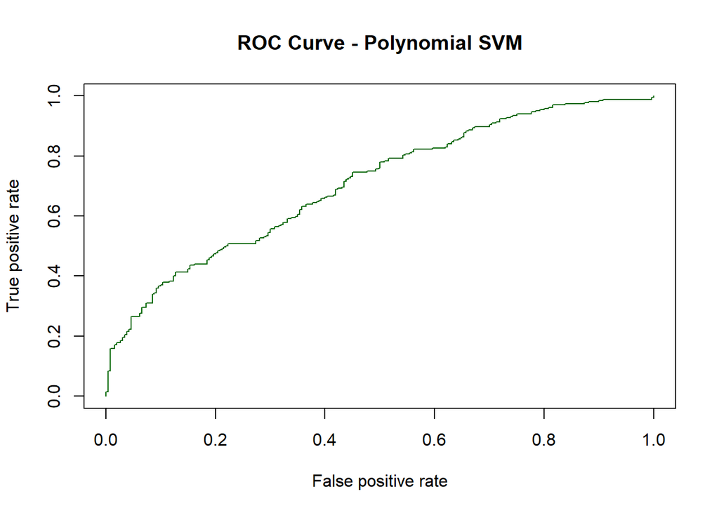

```r
# Re-train the best model with probability = TRUE
bestmod <- svm(
  ever_had_diabetes ~ .,
  data = train_scaled,
  kernel = "polynomial",
  cost = tune_model$best.parameters$cost,
  degree = tune_model$best.parameters$degree,
  probability = TRUE
)

# Predict on the test set with probabilities
svm_probs <- predict(bestmod, newdata = test_scaled, probability = TRUE)

# Extract the probabilities for class "Yes"
svm_probs_attr <- attr(svm_probs, "probabilities")
prob_yes <- svm_probs_attr[, "Yes"]

# Convert true labels to binary (0 = No, 1 = Yes)
truth <- ifelse(test_scaled$ever_had_diabetes == "Yes", 1, 0)

# Define ROC plotting function
rocplot <- function(pred, truth, ...) {
  predob <- prediction(pred, truth)
  perf <- performance(predob, "tpr", "fpr")
  plot(perf, ...)
}

# Plot the ROC curve
rocplot(prob_yes, truth, col = "darkgreen", main = "ROC Curve - Polynomial SVM")
```

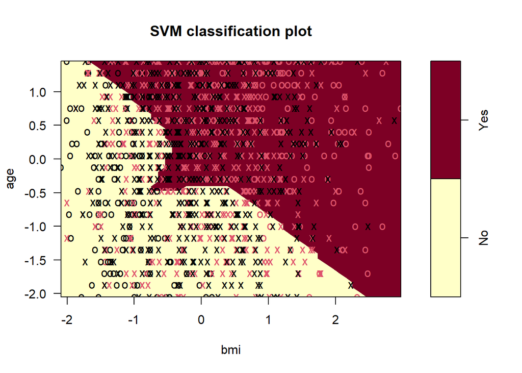

```r
### plots
plot(bestmod, train_scaled, age ~ bmi)
```

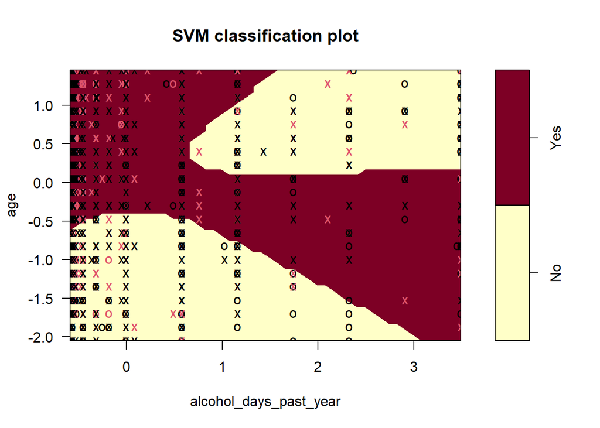

```r
plot(bestmod, train_scaled, age ~ alcohol_days_past_year)
```

### Radial SVM Model: Predicting Diabetes using Dietary Habits

```r
### Data cleaning Diet subset
library(e1071)

# subset data
diet <- nhis %>%
  select(ever_had_diabetes, fruit_intake, vegetable_intake, juice_intake, salad_intake,soda_intake, fried_potatoes_intake, fruit_drink_intake, pizza_intake)

# viewing some outliers
summary(diet)
```

```
##  ever_had_diabetes  fruit_intake    vegetable_intake  juice_intake
##  No :14888         Min.   :  0.00   Min.   :  0.00   Min.   :  0.00
##  Yes: 2704         1st Qu.:  1.00   1st Qu.:  1.00   1st Qu.:  0.00
##                    Median :  2.00   Median :  2.00   Median :  1.00
##                    Mean   : 39.06   Mean   : 41.18   Mean   : 37.17
##                    3rd Qu.:  4.00   3rd Qu.:  4.00   3rd Qu.:  2.00
##                    Max.   :999.00   Max.   :999.00   Max.   :999.00
##   salad_intake     soda_intake    fried_potatoes_intake fruit_drink_intake
##  Min.   :  0.00   Min.   :  0.0   Min.   :  0.00        Min.   :  0.0
##  1st Qu.:  1.00   1st Qu.:  0.0   1st Qu.:  1.00        1st Qu.:  0.0
##  Median :  2.00   Median :  0.0   Median :  1.00        Median :  0.0
##  Mean   : 38.38   Mean   : 35.5   Mean   : 37.58        Mean   : 35.3
##  3rd Qu.:  4.00   3rd Qu.:  2.0   3rd Qu.:  2.00        3rd Qu.:  0.0
##  Max.   :999.00   Max.   :999.0   Max.   :999.00        Max.   :999.0
##   pizza_intake
##  Min.   :  0.00
##  1st Qu.:  1.00
##  Median :  1.00
##  Mean   : 37.52
##  3rd Qu.:  2.00
##  Max.   :999.00
```

```r
# removing outlier values (anything greter than 100)
library(dplyr)
diet <- diet %>%
  filter(if_all(-ever_had_diabetes, ~ . <= 100))
summary(diet)
```

```
##  ever_had_diabetes  fruit_intake    vegetable_intake  juice_intake
##  No :14247         Min.   : 0.000   Min.   : 0.000   Min.   : 0.000
##  Yes: 2572         1st Qu.: 1.000   1st Qu.: 1.000   1st Qu.: 0.000
##                    Median : 2.000   Median : 2.000   Median : 1.000
##                    Mean   : 3.657   Mean   : 3.988   Mean   : 1.775
##                    3rd Qu.: 4.000   3rd Qu.: 4.000   3rd Qu.: 2.000
##                    Max.   :84.000   Max.   :90.000   Max.   :60.000
##   salad_intake     soda_intake      fried_potatoes_intake fruit_drink_intake
##  Min.   : 0.000   Min.   :  0.000   Min.   : 0.0          Min.   : 0.0000
##  1st Qu.: 1.000   1st Qu.:  0.000   1st Qu.: 0.0          1st Qu.: 0.0000
##  Median : 2.000   Median :  0.000   Median : 1.0          Median : 0.0000
##  Mean   : 3.385   Mean   :  1.568   Mean   : 1.9          Mean   : 0.5461
##  3rd Qu.: 4.000   3rd Qu.:  2.000   3rd Qu.: 2.0          3rd Qu.: 0.0000
##  Max.   :60.000   Max.   :100.000   Max.   :60.0          Max.   :45.0000
##   pizza_intake
##  Min.   : 0.000
##  1st Qu.: 1.000
##  Median : 1.000
##  Mean   : 1.439
##  3rd Qu.: 2.000
##  Max.   :30.000
```

```r
### Undersample classes
set.seed(1)

# Subset each class
no_cases <- diet[diet$ever_had_diabetes == "No", ]
yes_cases <- diet[diet$ever_had_diabetes == "Yes", ]

# Undersample 1000 from each class
no_sample <- no_cases[sample(nrow(no_cases), 1000), ]
yes_sample <- yes_cases[sample(nrow(yes_cases), 1000), ]

# Combine into a balanced, undersampled dataset
diet_undersampled <- rbind(no_sample, yes_sample)

# Shuffle rows
diet_undersampled <- diet_undersampled[sample(nrow(diet_undersampled)), ]

# Check result
table(diet_undersampled$ever_had_diabetes)
```

```
##
##   No  Yes
## 1000 1000
```

```r
### Radial SVM Model
set.seed(1)

# 70/30 train-test split
index <- sample(1:nrow(diet_undersampled), 0.7 * nrow(diet_undersampled))
train <- diet_undersampled[index, ]
test <- diet_undersampled[-index, ]

# Scale numeric predictors (excluding the target variable)
train_scaled <- train %>%
  mutate(across(-ever_had_diabetes, scale))

test_scaled <- test %>%
  mutate(across(-ever_had_diabetes, scale))

# (b) Fit the SVM model
svm_model <- svm(ever_had_diabetes ~ ., data = train_scaled, kernel = 'radial', gamma =1, cost = 1)

# Summary statistics of SVM model
summary(svm_model)
```

```
##
## Call:
## svm(formula = ever_had_diabetes ~ ., data = train_scaled, kernel = "radial",
##     gamma = 1, cost = 1)
##
##
## Parameters:
##    SVM-Type:  C-classification
##  SVM-Kernel:  radial
##        cost:  1
##
## Number of Support Vectors:  1315
##
##  ( 653 662 )
##
##
## Number of Classes:  2
##
## Levels:
##  No Yes
```

```r
# (c) Training error
ypred_train <- predict(svm_model, newdata = train_scaled)
mean(ypred_train != train_scaled$ever_had_diabetes)
```

```
## [1] 0.2778571
```

```r
# (d) Test error
ypred_test <- predict(svm_model, newdata = test_scaled)
mean(ypred_test != test_scaled$ever_had_diabetes)
```

```
## [1] 0.4716667
```

```r
### Confusion Matrix
true_values <- test_scaled$ever_had_diabetes
predicted_values <- predict(svm_model, newdata = test_scaled)

conf_matrix <- table(true = true_values, pred = predicted_values)
conf_matrix
```

```
##      pred
## true   No Yes
##   No  168 133
##   Yes 150 149
```

```r
# (e) Cross-validation for Radial SVM Model

# (f) Cross-validation for tuning the radial SVM model
set.seed(1)
tune_model <- tune(svm, ever_had_diabetes ~ .,
                   data = train_scaled,
                   kernel = "radial",
                   ranges = list(cost = c(0.1, 1, 5, 10, 50),
                                 gamma = c(0.001, 0.01, 0.1, 0.5, 1)),
                   tunecontrol = tune.control(cross = 5))

# Pick the best model based on cross-validation results
bestmod <- tune_model$best.model
tune_model$best.parameters$gamma
```

```
## [1] 0.1
```

```r
summary(bestmod)
```

```
##
## Call:
## best.tune(METHOD = svm, train.x = ever_had_diabetes ~ ., data = train_scaled,
##     ranges = list(cost = c(0.1, 1, 5, 10, 50), gamma = c(0.001, 0.01,
##         0.1, 0.5, 1)), tunecontrol = tune.control(cross = 5), kernel = "radial")
##
##
## Parameters:
##    SVM-Type:  C-classification
##  SVM-Kernel:  radial
##        cost:  5
##
## Number of Support Vectors:  1287
##
##  ( 640 647 )
##
##
## Number of Classes:  2
##
## Levels:
##  No Yes
```

```r
# (g) Training error for the best model
ypred_best <- predict(bestmod, newdata = train_scaled)
mean(ypred_best != train_scaled$ever_had_diabetes)
```

```
## [1] 0.3692857
```

```r
# (h) Test error for the best model
ypred_best_test <- predict(bestmod, newdata = test_scaled )
mean(ypred_best_test != test_scaled $ever_had_diabetes)
```

```
## [1] 0.4683333
```

```r
### Confusion Matrix
true_values <- test_scaled $ever_had_diabetes
predicted_values <- predict(bestmod, newdata = test_scaled )

conf_matrix <- table(true = true_values, pred = predicted_values)
conf_matrix
```

```
##      pred
## true   No Yes
##   No  127 174
##   Yes 107 192
```

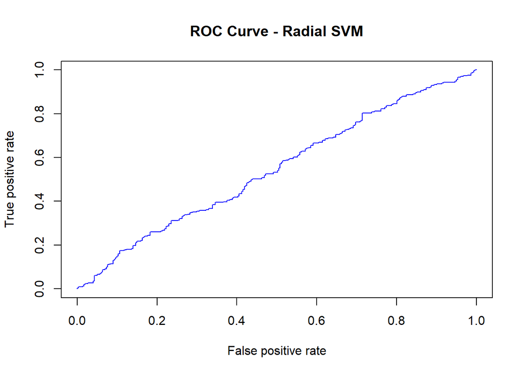

```r
### ROC CURVE
library(ROCR)

# Re-train radial SVM with probability = TRUE
bestmod <- svm(
  ever_had_diabetes ~ .,
  data = train_scaled,
  kernel = "radial",
  cost = tune_model$best.parameters$cost,
  gamma = tune_model$best.parameters$gamma,
  probability = TRUE
)

# Predict on test set with probability output
svm_probs <- predict(bestmod, newdata = test_scaled, probability = TRUE)

# Extract probabilities for class "Yes"
svm_probs_attr <- attr(svm_probs, "probabilities")
prob_yes <- svm_probs_attr[, "Yes"]

# Convert true labels to binary (0 = No, 1 = Yes)
truth <- ifelse(test_scaled$ever_had_diabetes == "Yes", 1, 0)

# Define the ROC plotting function
rocplot <- function(pred, truth, ...) {
  predob <- prediction(pred, truth)
  perf <- performance(predob, "tpr", "fpr")
  plot(perf, ...)
}

# Plot ROC
rocplot(prob_yes, truth, col = "blue", main = "ROC Curve - Radial SVM")
```

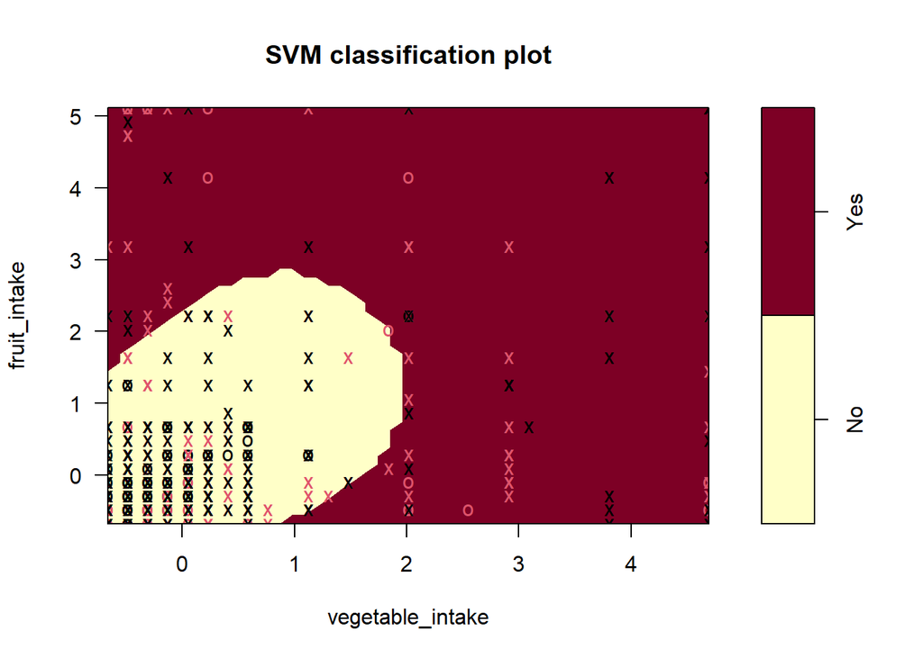

```r
### Plots
plot(bestmod, train_scaled, fruit_intake ~ vegetable_intake)
```

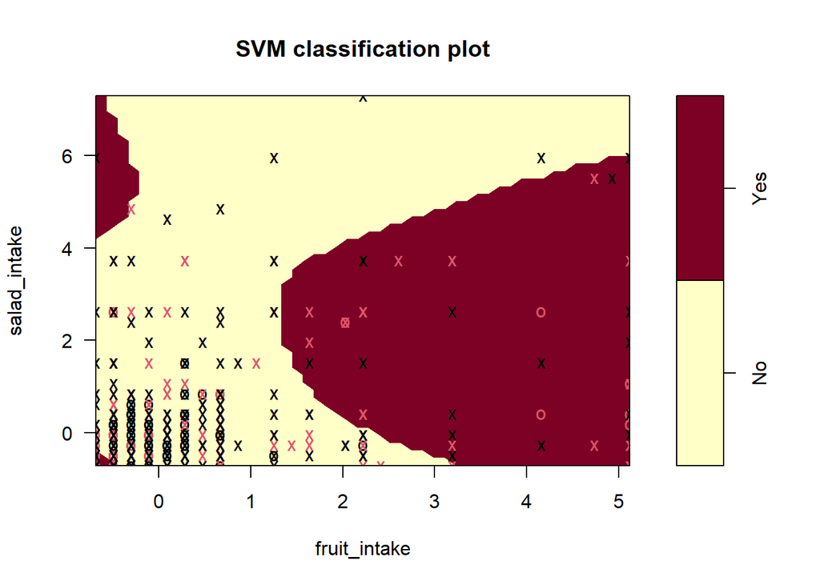

```r
plot(bestmod, train_scaled, salad_intake ~ fruit_intake)
```

### Testing Linear SVM: Predicting Diabetes using Dietary Habits

** Check if Radial model is too complex or if dietary habits simply does not explain diabetes

```r
### Cross-Validation Linear SVM

# (d) Cross-validation on SVM models
set.seed(1)
tune_model <- tune(
  svm, ever_had_diabetes ~ ., data = train_scaled,
  kernel = "linear",
  ranges = list(cost = c(1, 5, 10, 50, 100))
)

# Pick best model
tune_model$best.parameters
```

```
##   cost
## 1    1
```

```r
bestmod <- tune_model$best.model
summary(bestmod)
```

```
##
## Call:
## best.tune(METHOD = svm, train.x = ever_had_diabetes ~ ., data = train_scaled,
##     ranges = list(cost = c(1, 5, 10, 50, 100)), kernel = "linear")
##
##
## Parameters:
##    SVM-Type:  C-classification
##  SVM-Kernel:  linear
##        cost:  1
##
## Number of Support Vectors:  1340
##
##  ( 670 670 )
##
##
## Number of Classes:  2
##
## Levels:
##  No Yes
```

```r
# (e) Training error with best model
sum(predict(bestmod, train_scaled) != train_scaled$ever_had_diabetes)/nrow(train_scaled)
```

```
## [1] 0.4757143
```

```r
# Test error with best model
sum(predict(bestmod, test_scaled) != test_scaled$ever_had_diabetes)/nrow(test_scaled)
```

```
## [1] 0.4783333
```